# HJA_DIRT20_analysis

Derek Pierson

February 25, 2019

# *NEXT STEPS*

- Convert boxplots to bar graphs with std error bars. (reqs summary stats)
- Analyze bulk soil C over time
- Analyze bulk density dataset
- Reproduce plots for N content
- Stats: Mean comparisons
- Secondary datasets: N-min, pH, root mass

**Add interpretations/hypotheses in captions below figures**

# H.J. Andrews DIRT - 20 Year Analysis

This document contains the R analysis and figures for the H.J. Andrews DIRT 20 year sampling event. Sampling was done in June-July 2017.

## Rough Outline For The Paper

This paper addresses the question: How do detrital source, quantity and quality influence soil C stabilization? (in this case, specific to andic soils in a wet temperate forest dominated by old-growth Douglas fir). The experiment used to answer our research question is the DIRT manipulation at H.J. Andrews. After twenty years of DIRT manipulations, we now present results from the experiment pertaining to the following soil properties:

- Bulk soil C% at 0-10, 10-20, 20-40, 40-60 & 60-100 cm, across treatments (Figure 1)
- Bulk density at 0-5, 5-10 & 10-15 cm (Figure 2)
- Bulk soil C as stocks (Figure 3)
- Soil C fractions (heavy, intermediate and light) at depths 0-10 & 10-20 cm (Figure 4)
- If most relevant to this paper, also FTICR MS of bulk soil C (Figure 5)
- If insightful, change in bulk soil C at 0-10 cm at year 10, 15 and 20.
- If insightful, bulk soil N by depth
- Other soil properties measured: pH, N-mineralization rate (Table), root weight, monthly soil temperature

## Datasets

#### Dataset 1: Bulk and fractionated soil C and N concentration by plot and depth.

```r
data.1 <- read.csv("DIRT20_soil_master_raw.csv", as.is=T, skip=1)  #Load data as data.1
kable(data.1[1:8,], caption = "Data table structure")  #Display first few rows of the table
```

Data table structure

| DNPF | Plot | Treatment | TRT | Depth | bulk_percC | bulk_percN | LF_wt | LF_percC | LF_percN | IF_wt | IF_percC | IF_percN | HF_wt | HF_percC | HF_percN |
| --- | --- | --- | --- | --- | --- | --- | --- | --- | --- | --- | --- | --- | --- | --- | --- |
| 1 | 1 | No Root | NR | 0-10 | 5.77 | 0.251 | 3.77 | 31.81 | 0.791 | 12.90 | 4.58 | 0.302 | 20.80 | 1.45 | 0.101 |
| 2 | 2 | Double Litter | DL | 0-10 | 3.59 | 0.175 | 2.77 | 31.34 | 0.856 | 11.89 | 4.17 | 0.298 | 23.14 | 1.22 | 0.084 |
| 3 | 3 | No Litter | NL | 0-10 | 5.73 | 0.209 | 4.08 | 32.90 | 0.775 | 9.77 | 5.23 | 0.310 | 23.80 | 1.03 | 0.073 |
| 4 | 4 | No Root | NR | 0-10 | 4.04 | 0.206 | 2.18 | 31.78 | 0.728 | 7.06 | 3.83 | 0.315 | 29.19 | 1.09 | 0.097 |
| 5 | 5 | Double Wood | DW | 0-10 | 3.73 | 0.160 | 4.71 | 23.65 | 0.531 | 8.65 | 2.84 | 0.190 | 25.13 | 0.89 | 0.073 |
| 6 | 6 | No Root | NR | 0-10 | 5.38 | 0.223 | 5.88 | 26.39 | 0.589 | 8.73 | 5.13 | 0.333 | 23.69 | 1.38 | 0.106 |
| 7 | 7 | No Litter | NL | 0-10 | 4.12 | 0.184 | 5.42 | 26.65 | 0.562 | 8.90 | 3.94 | 0.281 | 23.24 | 1.06 | 0.083 |
| 8 | 8 | Control | CTL | 0-10 | 4.17 | 0.186 | 5.05 | 21.26 | 0.551 | 12.37 | 2.99 | 0.194 | 20.02 | 1.10 | 0.096 |

#### Dataset 2: Bulk soil C over time, years 10, 15 and 20

**To be continued…**

#### Dataset 3: Bulk density and soil C and N by plot, in 5 cm increments from 0-15 cm

**To be continued…**

## Bulk soil C

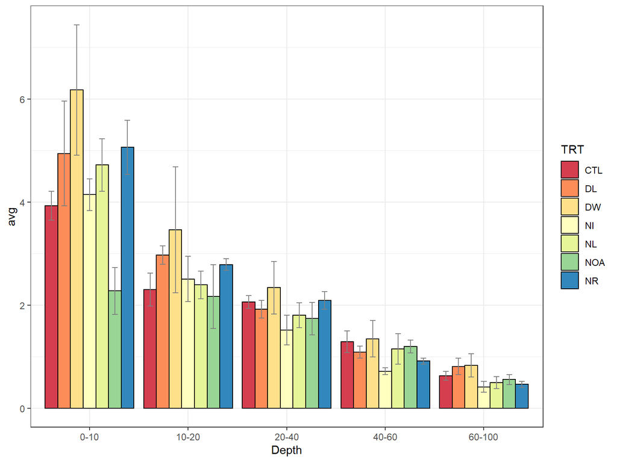

```r
### Plot soil  percent C by treatment & depth

#Summarize data to get mean and std error
data.1_sumbulkC <- data.1 %>% group_by(.dots=c("TRT", "Depth")) %>%
                      summarize(avg=mean(bulk_percC), n=n(), sd=sd(bulk_percC), se=sd/sqrt(n))

ggplot(data.1_sumbulkC, aes(x=Depth, y=avg, group=TRT, fill=TRT)) + theme_bw() +
    geom_bar(position=position_dodge(), stat="identity", colour="black") +
    geom_errorbar(aes(ymin=avg-se, ymax=avg+se),width=.4,position=position_dodge(.9), color="grey50") +
    scale_fill_brewer(palette="Spectral")
```

### Modified C content for 0-10 cm

Interpretation of the treatment effects is largely affected by the mean soil C value from the control plots. From the primary sampling in July 2017, these values were lower than expected. To validate the initial sampling data, we sampled on multiple (4x total) other occasions up through February 2018. Below, I have revised the plot using an average of all four samplings from the 0-10cm control plots. The mean C does rise, but remains somewhat low compared to expectations. I foresee we can easily justify using this slightly higher value, but in that case, it would be appropriate to use the average from all sampling for the rest of the treatments as well. Moving forward, we should be cognizant of how these small shifts in control C change our interpretation of the results (How much does this shift matter to the story?)

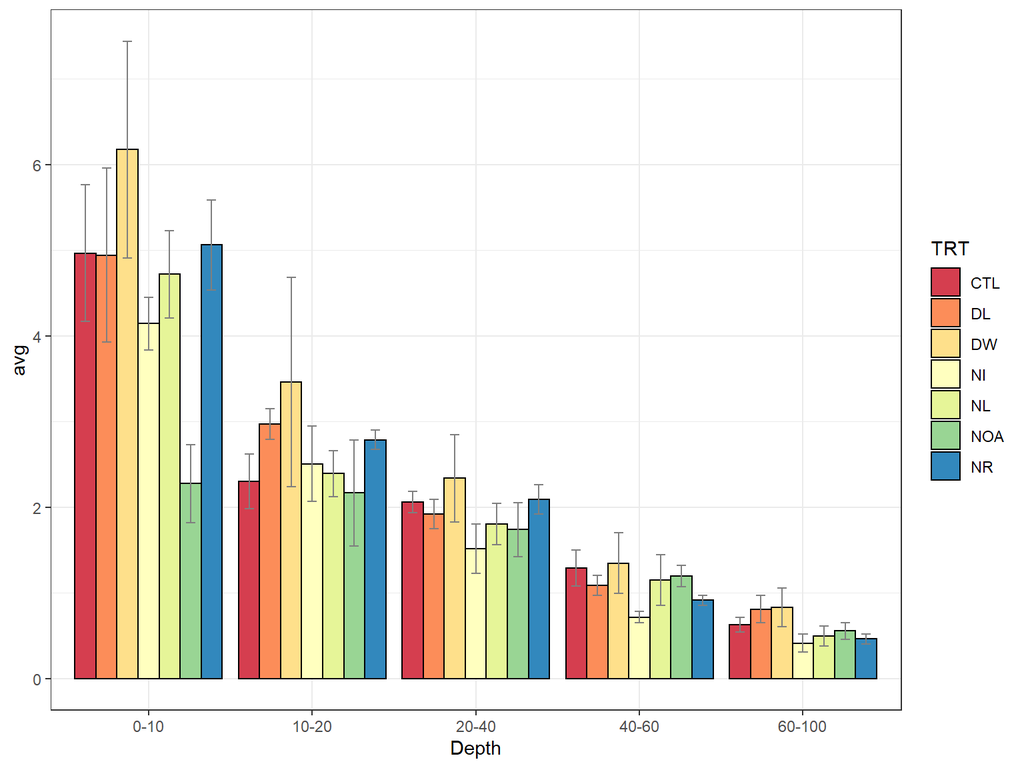

```r
## Plot as bars with std error
# Create modified dataframe for averaged 0-10 cm control C
data.1m <- data.1

# Values are averages from all samplings July 2017 - Feb 2018
data.1m[8,6] <- 4.836
data.1m[12,6] <- 6.407 # This value from plot 12 is where we get the boost
data.1m[14,6] <- 3.66

#summarize data for bulk C percent
data.1m_sumbulkC <- data.1m %>% group_by(.dots=c("TRT", "Depth")) %>%
                      summarize(avg=mean(bulk_percC), n=n(), sd=sd(bulk_percC), se=sd/sqrt(n))

### Plot soil  percent C by treatment & depth
library(RColorBrewer)
ggplot(data.1m_sumbulkC, aes(x=Depth, y=avg, group=TRT, fill=TRT)) + theme_bw() +
    geom_bar(position=position_dodge(), stat="identity", colour="black") +
    geom_errorbar(aes(ymin=avg-se, ymax=avg+se),width=.4,position=position_dodge(.9), color="grey50") +
    scale_fill_brewer(palette="Spectral")
```

## Bulk soil C over time

## Soil Bulk Density

## Soil C stocks

### Soil C stocks to 1 m

**To be continued…** Soil C% x Bulk density x Depth

## Fractionated soil C

**Missing two heavy fraction values:**

- DNPF 38, Double litter, 10-20 cm
- DNPF 42, No input, 10-20 cm

### Heavy Fraction Soil C

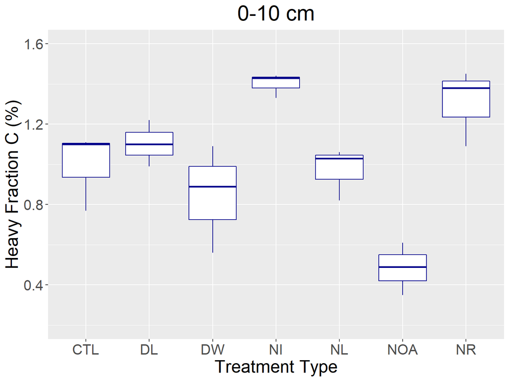

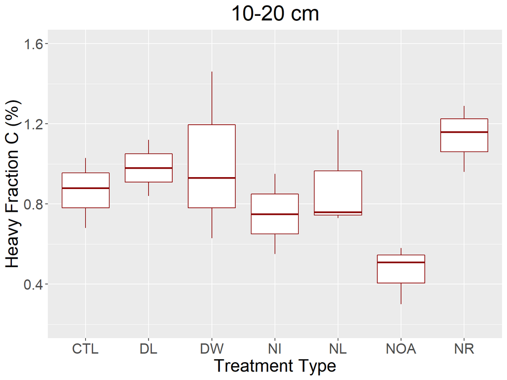

```r
#Create data frame with only the fractionated sample data
data.1f <- data.1 %>% filter(grepl("0-10|10-20", Depth)) %>% filter(Depth != "60-100")

### Plot 0-10 cm heavy fraction soil percent C
ggplot(data.1f %>% filter(Depth == "0-10"), aes(x=TRT, y=HF_percC)) +
  geom_boxplot(data=data.1f %>% filter(Depth == "0-10"), color="darkblue") +
  scale_color_brewer(palette="Set1") +
  scale_fill_brewer(palette="Set1") +
  ggtitle("0-10 cm") +
  xlab("Treatment Type") + ylab("Heavy Fraction C (%)") +
  theme(legend.position="none", plot.title = element_text(hjust = 0.5), text = element_text(size=20)) +
  ylim(0.2,1.6)

### Plot 10-20 cm heavy fraction soil percent C
ggplot(data.1f %>% filter(Depth == "10-20"), aes(x=TRT, y=HF_percC)) +
  geom_boxplot(data=data.1f %>% filter(Depth == "10-20"), color="darkred") +
  scale_color_brewer(palette="Set1") +
  scale_fill_brewer(palette="Set1") +
  ggtitle("10-20 cm") +
  xlab("Treatment Type") + ylab("Heavy Fraction C (%)") +
  theme(legend.position="none", plot.title = element_text(hjust = 0.5), text = element_text(size=20)) +
  ylim(0.2,1.6)
```

### Intermediate Fraction Soil C

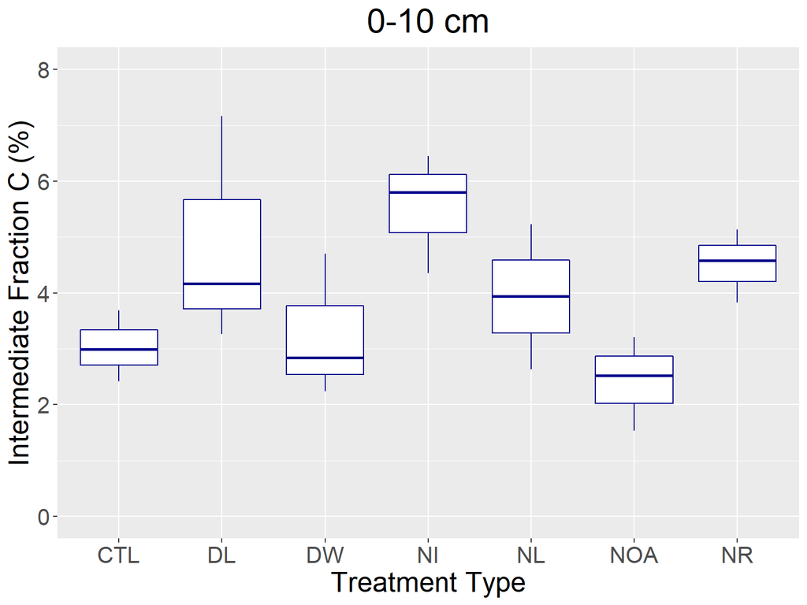

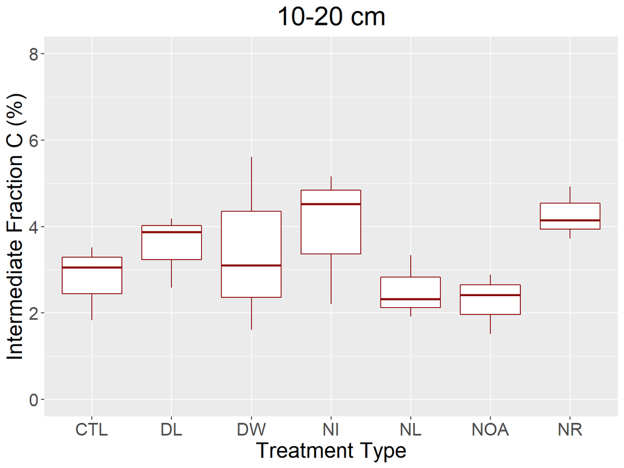

```r
#Create data frame with only the fractionated sample data
data.1f <- data.1 %>% filter(grepl("0-10|10-20", Depth)) %>% filter(Depth != "60-100")

### Plot 0-10 cm intermediate fraction soil percent C
ggplot(data.1f %>% filter(Depth == "0-10"), aes(x=TRT, y=IF_percC)) +
  geom_boxplot(data=data.1f %>% filter(Depth == "0-10"), color="darkblue") +
  scale_color_brewer(palette="Set1") +
  scale_fill_brewer(palette="Set1") +
  ggtitle("0-10 cm") +
  xlab("Treatment Type") + ylab("Intermediate Fraction C (%)") +
  theme(legend.position="none", plot.title = element_text(hjust = 0.5), text = element_text(size=20)) +
  ylim(0,8)

### Plot 10-20 cm intermediate fraction soil percent C
ggplot(data.1f %>% filter(Depth == "10-20"), aes(x=TRT, y=IF_percC)) +
  geom_boxplot(data=data.1f %>% filter(Depth == "10-20"), color="darkred") +
  scale_color_brewer(palette="Set1") +
  scale_fill_brewer(palette="Set1") +
  ggtitle("10-20 cm") +
  xlab("Treatment Type") + ylab("Intermediate Fraction C (%)") +
  theme(legend.position="none", plot.title = element_text(hjust = 0.5), text = element_text(size=20)) +
  ylim(0,8)
```

### Light Fraction Soil C

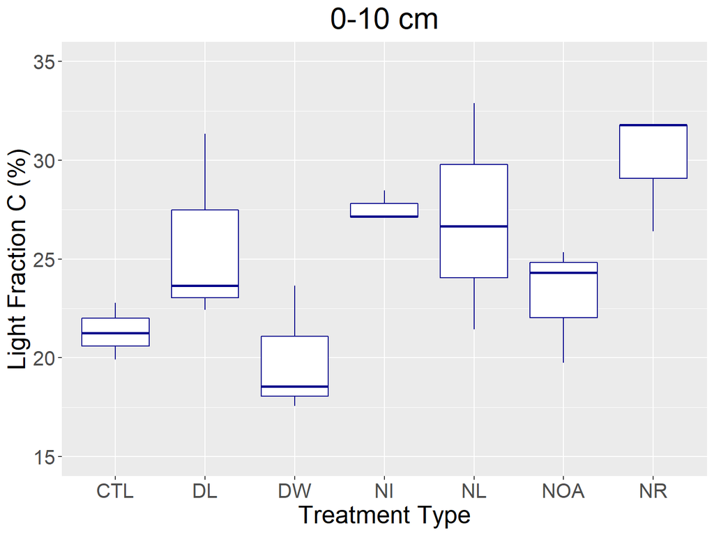

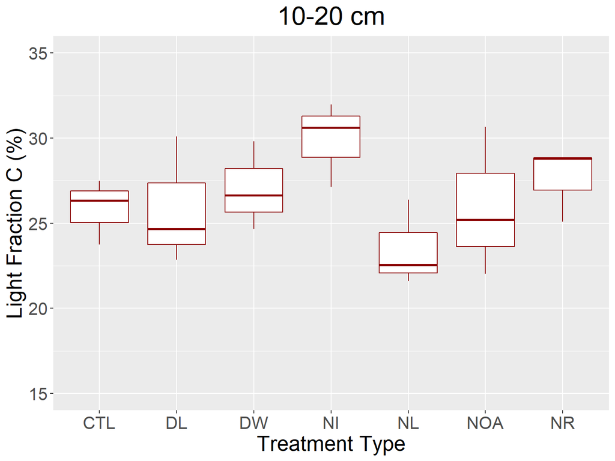

```r
#Create data frame with only the fractionated sample data
data.1f <- data.1 %>% filter(grepl("0-10|10-20", Depth)) %>% filter(Depth != "60-100")

### Plot 0-10 cm light fraction soil percent C
ggplot(data.1f %>% filter(Depth == "0-10"), aes(x=TRT, y=LF_percC)) +
  geom_boxplot(data=data.1f %>% filter(Depth == "0-10"), color="darkblue") +
  scale_color_brewer(palette="Set1") +
  scale_fill_brewer(palette="Set1") +
  ggtitle("0-10 cm") +
  xlab("Treatment Type") + ylab("Light Fraction C (%)") +
  theme(legend.position="none", plot.title = element_text(hjust = 0.5), text = element_text(size=20)) +
  ylim(15,35)

### Plot 10-20 cm light fraction soil percent C
ggplot(data.1f %>% filter(Depth == "10-20"), aes(x=TRT, y=LF_percC)) +
  geom_boxplot(data=data.1f %>% filter(Depth == "10-20"), color="darkred") +
  scale_color_brewer(palette="Set1") +
  scale_fill_brewer(palette="Set1") +
  ggtitle("10-20 cm") +
  xlab("Treatment Type") + ylab("Light Fraction C (%)") +
  theme(legend.position="none", plot.title = element_text(hjust = 0.5), text = element_text(size=20)) +
  ylim(15,35)
```

### Fraction mass proportions

## O-horizon C

### O-horizon depth

### 0-horizon bulk C

## Root weights

### Root C estimate –> Soil C potential increase magnitude

## Soil pH

## Soil temperature

## Soil nitrogen

### Soil Total N

### Soil N-min

## FT-ICR MS